# Introduction

The objective of this project was to wrangle WeRateDogs Twitter data to create interesting and reliable analyses and visualization. WeRatesDogs downloaded their Twitter data and provided it to Udacity for us. Beside gathering, assessing, and cleaning, it was required to come up with this analysis and visualization report.

# Insights about Data (Analysis and Visualizations)

Data was collected from different sources. The first data 'twitter-archive-enhanced.csv' was downloaded from the link as given in the project and the CSV file was then uploaded in the notebook. The CSV file was imported into the dataframe named as twitter_archive.

The second data ‘image-predictions.tsv’ was extracted programmatically from a URL which was given in the instructions to do the project. To extract the data the request library was imported by ' import requests' command. The TSV file was imported into the dataframe named as image_predictions.

The third data ‘tweet_json.txt’ was extracted programmatically from WeRateDog twitter account. To extract the data the tweepy library was imported by ' import tweepy' command. Each tweet_id was accessed by using the Twitter API and wrote each line to the file ‘tweet_json.txt’. The TXT file was imported into the dataframe named as tweet_json.

Data quality and tidiness was checked visually and programmatically. First, the datasets were checked visually for quality or tidiness issues. Second, the data was checked programmatically to gain more insights about it. To print a concise summary of the data pandas info() method was used. This method prints information about the data including the index dtype and column dtypes, non-null values and memory usage. To analyzes both numeric and object series pandas describe() method was implemented. Duplicates columns and values were checked as well. tweet_id was a duplicate column within the datasets. There was not duplicates entries.

The data twitter_archive presented missing expanded_urls entries, inaccurate names in names columns, and incorrect datatype for timestamp column. The data image_predictions exhibited inconsistent letter cases for p1, p2, p3 columns. The data tweet_json had incorrect datatypes.

Before starting the data cleaning, a copy of all datasets was made. Quality and tidiness issues such as the one mentioned previously were fixed either by removing columns and rows that have missing or have unnecessary data, incorrect datatypes were changes to the right ones, letter capitalization inconsistencies were fix too.

The data was consolidated into one dataset named as ‘twitter_archive_master.csv’ after it was cleaned.

Part of this project include an interesting and trustworthy analyses and visualizations. In order to get the below histogram, library such as 'import matplotlib.pyplot as plt' and 'import seaborn as sns' were imported. The digrams style was set to darkgrid using seaborn build methods. I wanted to know about the tweets source distribution. Twitter Mobile App is desire user application and Tweet Web Client is not.

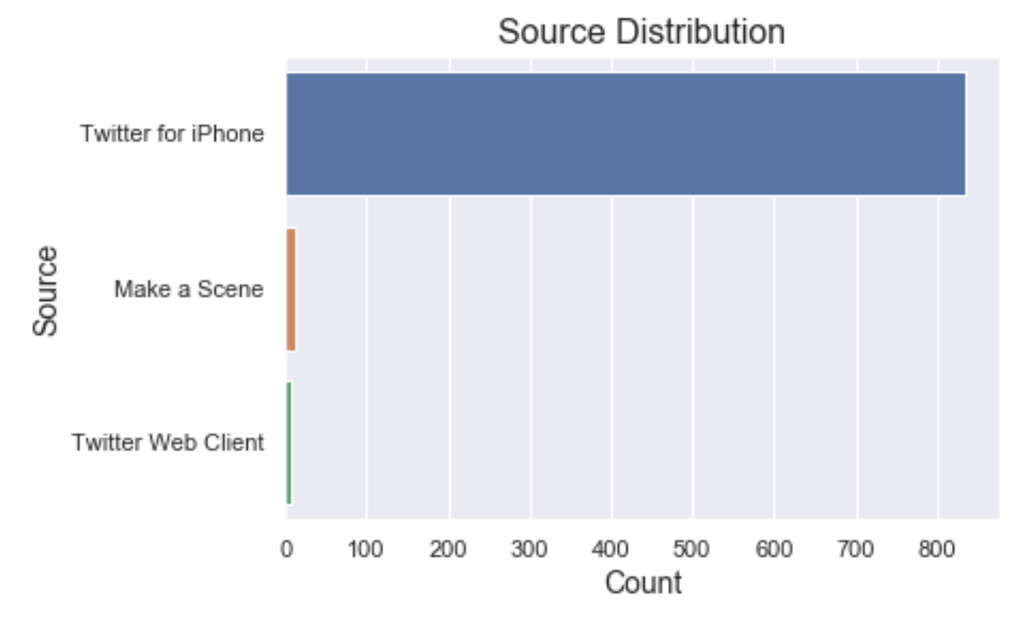

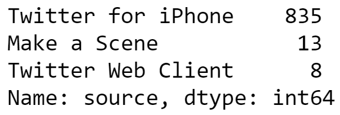

The correlation between favorites and retweets was computed. To compute pairwise correlation of columns, excluding NA/null values pandas 'corr()' was implemeted. A scatterplot about this correlation was created using matplotlib and seaborn. This library were imported previously. After calculating and visualizing the favorites and retweets correlation we can confirm that the favotires tweet usually gets the most retweets.

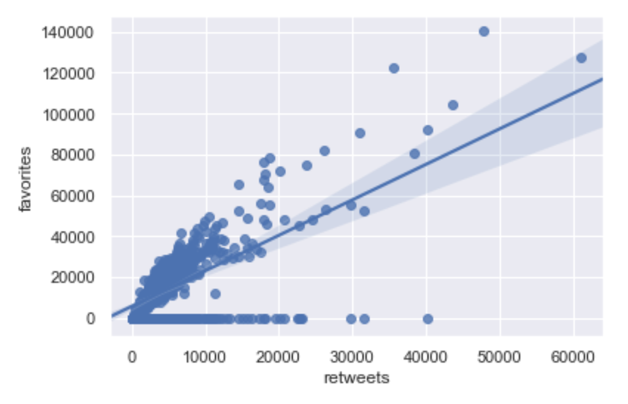

# Conclusion